# Time-Varying Ideal Points

Robert Kubinec

2024-11-18

*Note: To report bugs with the package, please file an issue on the [Github page](https://github.com/saudiwin/idealstan/issues).*

**If you use this package, please cite the following:**

Kubinec, Robert. “Generalized Ideal Point Models for Robust Measurement with Dirty Data in the Social Sciences.”

```r
data('delaware')
knitr::kable(slice(delaware,1:10))
```

| outcome | item_id | person_id | group_id | time_id |
| --- | --- | --- | --- | --- |
| NA | 1 | Atkins, John 1 | R | 1995-01-01 |
| NA | 1 | Atkins, John 2 | D | 1995-01-01 |
| Yes | 1 | Banning 3 | D | 1995-01-01 |
| NA | 1 | Barbieri, Michael A. 4 | D | 1995-01-01 |
| NA | 1 | Baumbach, Paul S. 5 | D | 1995-01-01 |
| NA | 1 | Bennett, Andria 6 | D | 1995-01-01 |
| NA | 1 | Bennett, E. 7 | D | 1995-01-01 |
| NA | 1 | Bentz, David 8 | D | 1995-01-01 |
| NA | 1 | Blakey, Donald 9 | R | 1995-01-01 |
| NA | 1 | Bolden, Stephanie 10 | D | 1995-01-01 |

The process to create a time-varying ideal point model is no different than that for creating a static model, except that a column should exist in the data with dates, preferably in `date` or `date-time` format. If you have a character vector of dates that you need to convert to R’s `date` format, check out the excellent [lubridate package](https://lubridate.tidyverse.org/).

There are four time-varying models included in `idealstan` package, each of which makes different assumptions about how ideal points change over time. It is important to note that none of these models is superior to the other. Ideal points do not have any natural time process as they are a latent, unobserved construct, so the question is more about which time process is most relevant to the social or physical process being studied. The models can be differentiated by whether they permit general description of time series versus inference on specific aspects, and also in terms of complexity.

The first kind of model included in `idealstan` is known as a random-walk process (also known as non-stationary time-series, Brownian motion and I(1)). This simple model of time implies that the location of an ideal point in the current time point is equal to the position of the ideal point in the prior time point plus some random noise. A helpful analogy is to imagine a frog hopping around a room. It could head in virtually any direction.

The advantage of the random-walk model is that it allows ideal points to move in any direction. The downside is that it can assume too much change in the ideal point process. It also does not provide a great deal of information about the time series other than the variance parameter of the time series that indicate the average rate of change over time (i.e., how bouncy the time series is). Furthermore, random-walk models change significantly when other covariates are included in the model, as an additional covariate that has a constant effect over time will push the time-series in a single direction, making it less than ideal for testing the effect of time-varying covariates.

Despite these limitations, this model is still useful, especially in two situations. First, when little is known about the time process/social situation, this model makes the most minimal assumptions about how ideal points change. Second, when the time series is of a relatively long time period, then the time series is likely to have some kind of random-walk nature, especially if there is no natural limit. For example, when looking at legislature voting data, ideal points may follow a random-walk pattern when looking at a legislator’s entire career over decades. In general, a random walk provides a good descriptive inference of where the ideal points are moving; it just won’t tell you a lot about *why*.

The second model included in `idealstan` is a stationary time series model (also called an AR(1) or first-order autoregressive time series). A stationary time-series is so called because it must return over time to a long-term average or mean. Change over time is conceived of as shocks that push the time series away from its long-term average. The AR(1) model includes additional parameters that measure how fast a time-series will return to its long-term average. A good empirical example for this model is economic growth over time. There are periods when “growth shocks” occur, such as recessions and boom times. Overall, though, economic growth for a specific country will tend towards some long-term average rate of growth. Economic growth can’t simply move off in any direction, especially in an upward direction, as that would over-heat the economy and result in massive inflation.

The third model is known as a Gaussian process. Fully explaining how Gaussian processes work is beyond the scope of this vignette, but I refer readers to [this case study](https://betanalpha.github.io/assets/case_studies/gp_part1/part1.html) as a very helpful introduction. A Gaussian process is similar to a random walk in that it can in principle move in any direction. Unlike a random walk, the prior position of the time series doesn’t necessarily constrain the position of the time series in the present position. Rather, a Gaussian process is a generalized smoother: it will find a smooth path between the points, but can take any shape in principle.

One major advantage of the Gaussian process is that it is a so-called continuous time series model. In practice this means that the time series does not have to be sequential. For example, if legislators only vote at irregular intervals, and the fact that some bills are separated than more time than others is important, then a Gaussian process will take into account the actual length of time between each vote. Random walks and stationary models, on the other hand, consider each time point to be sequential to the previous time point, effectively ignoring any big gaps.

The main disadvantage of the Gaussian process is that the power and flexbility require *a lot* more data. It is not a useful model unless you have considerable numbers of bills/items. The model can handle additional time-varying covariates although their meaning is not as precise as the stationary model.

The stationary model, by contrast, assumes that ideal points have a single long-term average. The ideal points may receive “shocks” that force them away from the long-term mean, but they will inevitably return. While this is a more specific set of assumptions than the random walk or Gaussian process, stationary models have the significant advantage of allowing us to fit covariates that have a more meaningful interpretation: the estimates of covariates represent shocks to the ideal points away from their long-term average.

A simpler kind of time series model is also available in `idealstan` known as splines. Splines are combinations of polynomial functions; the more combinations, the more flexible splines become. `idealstan` includes splines primarily because it is easy to estimate relatively simple time series functions that are useful when there is only a limited amount of data per time point and when the latent trait is unlikely change very quickly. In these cases, a spline can help estimate a latent trait that varies over time but only within certain bounds defined by the complexity of the polynomial function.

To show what these models look like, we will fit each model to the `delaware` data in turn. We use the `use_vb` option to produce variational estimates of the true posterior; these approximations are much faster to fit than the full model but usually have some distortions. For finished analysis we would want to use the full sampler (`use_vb=FALSE`), unless we have so much data that processing time for the full model is infeasible.

The models will be fit with parallel processing over the persons in the model (i.e. more `ncores` than `nchains` specified in `id_estimate`). Parallel processing is only possible for persons as time series model introduce dependence between time points. As such do not change the `map_over_id` option for dynamic models or you will get incorrect results.

## Random-Walk Model

To fit the random walk model, we first create data in which we pass the name of the column of dates for each bill/item to the `time_id` option of `id_make`. One important thing to note about this model is that we code missing values as `'Absent'`, but we leave `NA` values in the outcome. These `NA` values will be dropped before running the model. They represent periods of time when legislators were not in office, and hence it is reasonable to exclude these periods of time from analysis.

```r
# Absent to missing

delaware$outcome[delaware$outcome=="Absent"] <- NA

# adjust data to 0/1

delaware$outcome <- as.numeric(delaware$outcome=="Yes")

delaware_data <- id_make(delaware,outcome_disc = 'outcome',
                       person_id = 'person_id',
                       item_id = 'item_id',
                       group_id= 'group_id',
                       time_id='time_id')
```

One problem with time-varying models is that they introduce additional identification issues with the ideal point scores. Theoretically, if over-time variance is high enough, ideal point scores can oscillate from positive to negative. In these cases, you can add additional items to constrain via the `restrict_ind_high` and `restrict_ind_low` options or use a simpler time-series model like a spline with few degrees.

```r
# parallel processing over persons/legislators specified with
# ncores = 16 and nchains = 2
# this will equal 8 cores per chain.
# of course your machine must have 16 cores for
# that number to be useful

del_est <- id_estimate(delaware_data,
                model_type = 1,
                fixtype='prefix',const_type="items",
                nchains = 2,use_vb = T,
                ncores = 8,
                vary_ideal_pts='random_walk',
                 restrict_ind_high = 305,
                 restrict_ind_low=  276,
            seed=84520,
            id_refresh=0)
```

```
## [1] "Running pathfinder to find starting values"
## Finished in  8.1 seconds.
## [1] "Estimating model with Pathfinder for inference (approximation of true posterior)."
```

```
## Pareto k value (33) is greater than 0.7. Importance resampling was not able to improve the approximation, which may indicate that the approximation itself is poor.
## Finished in  7.6 seconds.
```

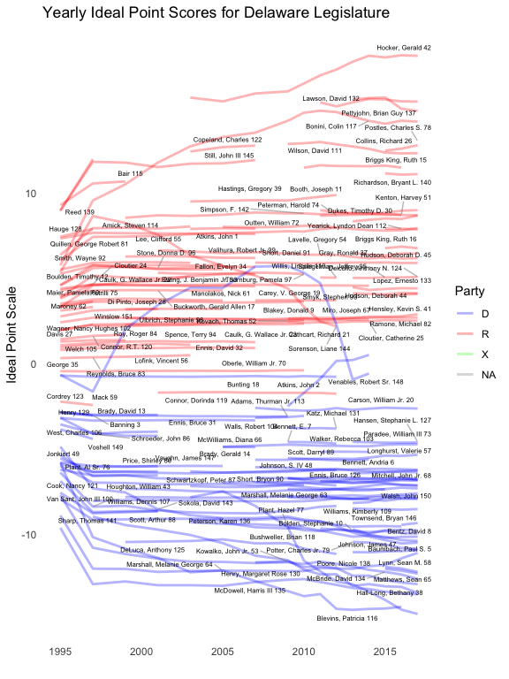

```r
id_plot_legis_dyn(del_est,use_ci = T) +
  scale_color_manual(values=c(R='red',
                              D='blue',
                              X='green'),
                     name="Party") +
  ggtitle("Yearly Ideal Point Scores for Delaware Legislature")
```

This plot does now show very much that is particularly interesting. Most of the ideal points are not changing over time, although it is important to note that polarization is increasing over time–both within parties and between parties as some legislators move to the extremes.

We can also look at the variance of the ideal points to see which of the legislators had the highest variance in their ideal points:

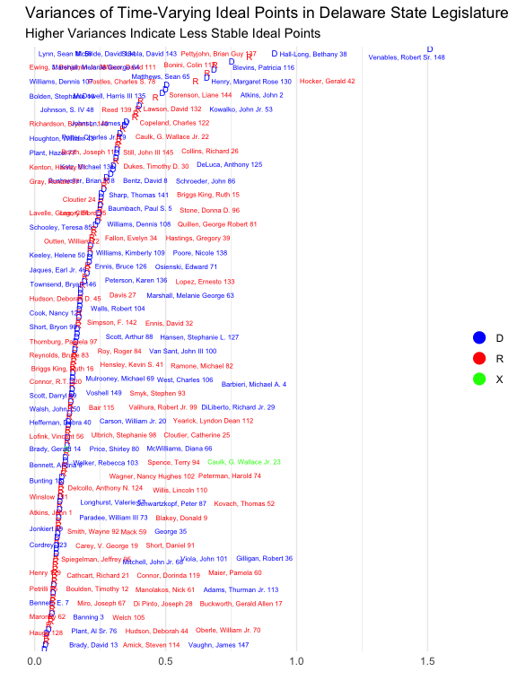

```r
id_plot_legis_var(del_est) + ggtitle('Variances of Time-Varying Ideal Points in Delaware State Legislature',subtitle='Higher Variances Indicate Less Stable Ideal Points') +
  scale_color_manual(values=c(R='red',
                              D='blue',
                              X='green'))
```

We can access the actual estimates of the variances by passing the `return_data=TRUE` option to the plot function:

```r
out_d <- id_plot_legis_var(del_est,return_data = T)
knitr::kable(head(out_d$plot_data))
```

| legis | low_pt | high_pt | median_pt | id_num | person_id | group_id |
| --- | --- | --- | --- | --- | --- | --- |
| time_var_free[100] | 0.6882220 | 0.6882220 | 0.6882220 | 100 | Pettyjohn, Brian Guy 137 | R |
| time_var_free[101] | 0.0534421 | 0.0534421 | 0.0534421 | 101 | Plant, Al Sr. 76 | D |
| time_var_free[102] | 0.2135720 | 0.2135720 | 0.2135720 | 102 | Plant, Hazel 77 | D |
| time_var_free[103] | 0.2105960 | 0.2105960 | 0.2105960 | 103 | Poore, Nicole 138 | D |
| time_var_free[104] | 0.3865460 | 0.3865460 | 0.3865460 | 104 | Postles, Charles S. 78 | R |
| time_var_free[105] | 0.3014740 | 0.3014740 | 0.3014740 | 105 | Potter, Charles Jr. 79 | D |

## Spline Model

We now fit a form of splines for the legislator trajectories by passing `'splines'` to `vary_ideal_pts`. This model has two main control parameters - `spline_degree` and `spline_knots`. The first is equal to the number of polynomial coefficients or “bends” in the time series – for a value of 2 the model is quadratic, with 3 it is a sigmoid (three bends), with 4 there is an additional possible bend in the time series, and so on. We will fit a restrictive time-varying model with 0 knots (equivalent to a single polynomial function) and only 2 degrees for the polynomial function:

```r
del_est_spline <- id_estimate(delaware_data,
                model_type = 1,
                fixtype='prefix',const_type="items",
                nchains=2,
                ncores=8,spline_knots = NULL,spline_degree = 2,
                vary_ideal_pts='splines',use_vb=TRUE,
                 restrict_ind_high = 305,
                 restrict_ind_low=276,
            seed=84520)
```

```
## [1] "Running pathfinder to find starting values"
## Finished in  5.9 seconds.
## [1] "Estimating model with Pathfinder for inference (approximation of true posterior)."
```

```
## Pareto k value (28) is greater than 0.7. Importance resampling was not able to improve the approximation, which may indicate that the approximation itself is poor.
## Finished in  6.5 seconds.
```

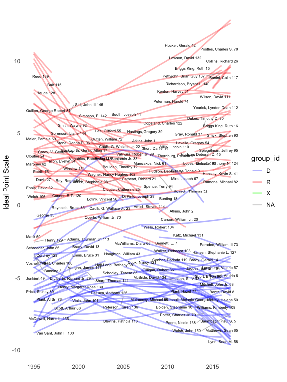

```r
id_plot_legis_dyn(del_est_spline,use_ci = F) +
  scale_color_manual(values=c(R='red',
                              D='blue',
                              X='green'))
```

Finally, we can also examine the individual ideal points by each time point using the summary function:

```r
summary(del_est_spline,pars='ideal_pts') %>%
  head %>%
  knitr::kable(.)
```

| Person | Group | Time_Point | Low Posterior Interval | Posterior Median | High Posterior Interval | Parameter Name |
| --- | --- | --- | --- | --- | --- | --- |
| NA | NA | NA | 1.542560 | 1.542560 | 1.542560 | L_tp1[1,100] |
| Plant, Al Sr. 76 | D | 1995-01-01 | -6.772590 | -6.772590 | -6.772590 | L_tp1[1,101] |
| NA | NA | NA | -5.216880 | -5.216880 | -5.216880 | L_tp1[1,102] |
| NA | NA | NA | -0.339099 | -0.339099 | -0.339099 | L_tp1[1,103] |
| NA | NA | NA | -0.128144 | -0.128144 | -0.128144 | L_tp1[1,104] |
| NA | NA | NA | -0.364884 | -0.364884 | -0.364884 | L_tp1[1,105] |

## Group-level Time-varying Ideal Points

Finally, we can also change the model’s parameters to look at group-level, i.e. party-level, ideal points. To do so we need to specify the `use_groups=T` option in the `id_estimate` function, and we change the restricted parameters to parties:

```r
del_est_rw3 <- id_estimate(delaware_data,
                fixtype='prefix',const_type="items",
                nchains=2,use_groups = T,
                ncores=8,use_vb=TRUE,
                 restrict_ind_high = 305,
                 restrict_ind_low=276,
                vary_ideal_pts='random_walk',
            seed=84520)
```

```
## [1] "Running pathfinder to find starting values"
## Finished in  90.6 seconds.
## [1] "Estimating model with Pathfinder for inference (approximation of true posterior)."
```

```
## Pareto k value (15) is greater than 0.7. Importance resampling was not able to improve the approximation, which may indicate that the approximation itself is poor.
## Finished in  97.0 seconds.
```

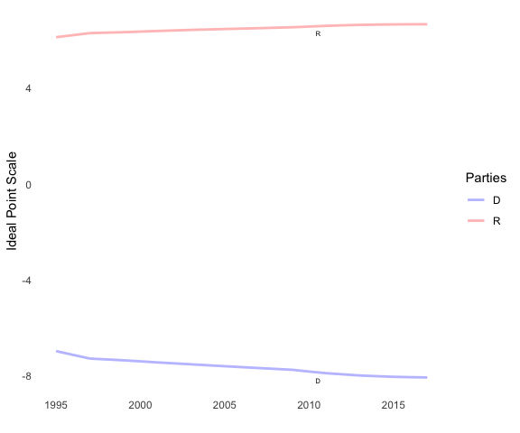

```r
id_plot_legis_dyn(del_est_rw3,
                  include=c('D','R')) + scale_colour_manual(values=c(R='red',
                                                          D='blue',
                                                          I='green'),
                                                 name="Parties")
```

We can also overlay a bill/item midpoint to see where the line of indifference in voting is relative to party positions. In a dynamic ideal point model, the bill/item midpoint will be a straight line as the bill-item midpoint was only voted on in one time point, and hence has only one parameter:

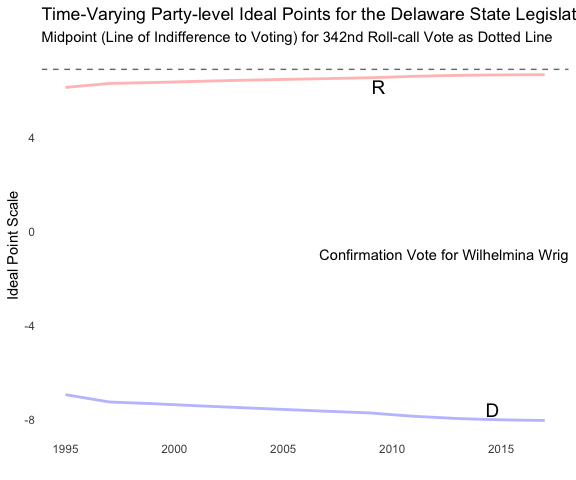

```r
id_plot_legis_dyn(del_est_rw3,item_plot='342',
                  text_size_label = 5,
                  include=c('D','R')) + scale_colour_manual(values=c(R='red',
                                                          D='blue',
                                                          I='green'),
                                                 name="Parties") +
  ggtitle('Time-Varying Party-level Ideal Points for the Delaware State Legislature',
          subtitle = 'Midpoint (Line of Indifference to Voting) for 342nd Roll-call Vote as Dotted Line') +
  guides(color='none') +
  annotate(geom='text',
           x = ymd('2016-01-01'),
           y=-1,
           label='Confirmation Vote for Wilhelmina Wright as U.S. District Judge')
```

I will now estimate an additional Gaussian process model to use as comparison points to the random-walk model for parties:

```r
del_est_gp1 <- id_estimate(delaware_data,
                fixtype='prefix',const_type="items",
                nchains=2,use_groups=T,
                ncores=8,use_vb=TRUE,
                 restrict_ind_high = 305,
                 restrict_ind_low=276,
                vary_ideal_pts='GP',
            seed=84520)
```

```
## [1] "Running pathfinder to find starting values"
## Finished in  76.3 seconds.
## [1] "Estimating model with Pathfinder for inference (approximation of true posterior)."
```

```
## Pareto k value (20) is greater than 0.7. Importance resampling was not able to improve the approximation, which may indicate that the approximation itself is poor.
## Finished in  50.1 seconds.
```

We can then examine the distributions for both models as plots:

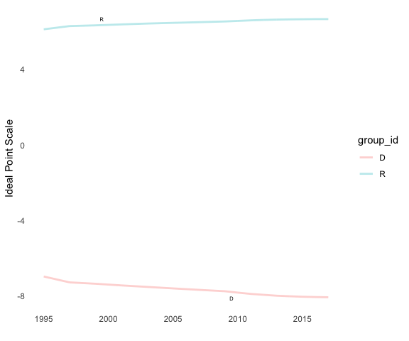

```r
id_plot_legis_dyn(del_est_rw3,include=c('D','R'))
```

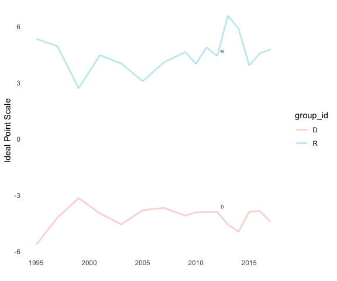

```r
id_plot_legis_dyn(del_est_gp1,include=c('D','R'))
```

We could also consider adjusting GP-specific parameters to force a more restrictive fit, though that type of prior adjustment depends on the particular dataset and context. These parameters are given defaults that restrict movement in the ideal points to help ensure identification. As such, they tend to be fairly conservative, but they can be made even more so when necessary. The table below shows these parameters’ values.

Parameters in the Gaussian Process Time-Series Model

[output not shown]